# Modelling Coevolution in Continuous Space

## Coevolution can lead to

spatial mosaics of phenotypic and genomic diversity

- Classically: interspecific spatial correlation $\implies$ coevolution
  - Not true since other processes can generate correlation
  - In particular, spatial autocorrelation due to limited dispersal

## Two projects

focused on disentangling spatial patterns due to

coevolution, limited dispersal and drift

- Phenotypic (math)
- Genomic (slim)
- Focusing on phenotypic model today

## Goals

- Approximate spatial scales of phenotypic turnover and coadaptation
- Introduce measures of local adaptation for continuously distributed populations
- Use results to determine which species is locally adapted
  - As function of relative dispersal abilities and strengths of selection
- Test accuracy of math using simulations (*not* slim)
  - Benefit: allows us to relax key assumptions
  - Cost: mapping simulation parameters to math parameters is hard
    - e.g. no such thing as interaction radius in math model

## The model

- 2D habitat
- Offspring location bivariate normal around parental location
- Interaction is host-parasite
- Single trait mediates interaction
- Drift captured by Gaussian noise in evolution of (local) mean traits

## Key assumptions

- Spatially homogeneous:
  - abundance densities
  - additive genetic and phenotypic variances
- Weak coevolutionary selection

## Spatial scales of phenotypic turnover

$$\xi_H = \frac{\sigma_H}{\sqrt{G_H(A_H-B_H)}}, \ \xi_P = \frac{\sigma_P}{\sqrt{G_P(A_P+B_P)}}$$

- $\sigma_H,\sigma_P=$ dispersal distances
- $G_H,G_P=$ additive genetic variances
- $A_H,A_P=$ strengths of abiotic selection
- $B_H,B_P=$ strengths of biotic selection

## Spatial scale of coadaptation?

- Spatial (interspp) cross-cov function analytically intractable
- How to measure spatial scale of coadaptation?
- Plan:
  1. Numerically compute cross-cov function
  2. Fit a widely-employed spatial cov function to theoretical result
  3. Fit same function to simulated results to assess accuracy

## Local adaptation

$$\mathcal{L}_H = -B_H\mathrm{Cov}(\bar z_H,\bar z_P)$$

$$\mathcal{L}_P = B_P\mathrm{Cov}(\bar z_H,\bar z_P)$$

- $\bar z_H,\bar z_P=$ local mean traits
- $B_H,B_P=$ strengths of biotic selection

## Local adaptation as function of relative dispersal distances

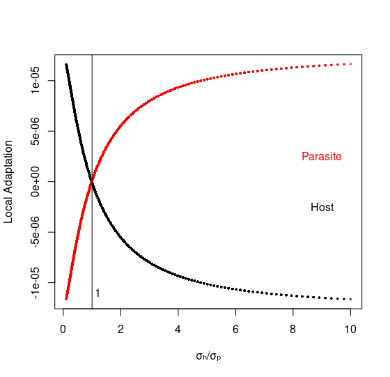

## Testing theory with simulations

- Individual-based simulations
- Requires fitness functions (expd offspg num)
  - Theory uses growth rates
  - How to relate?
- Math! (theory of diffusion-limits in particular)

## Mapping parameters

Additive genetic variance

$$G_P\approx \sqrt{\mu_P/(A_P+B_P)}$$

Population density

$$\rho_P\approx \frac{1}{\ln\kappa_P}\Big(r_P-\frac{1}{2}\sqrt{\mu_P(A_P+B_P)}\Big),$$

Growth rate

$$r_P\approx\ln\alpha_P+\pi_{\max}(\iota_P-1)\big(1-e^{-2\pi R_\iota^2\rho_H}\big),$$

Strength of biotic selection

$$B_P\approx\gamma\pi_{\max}(\iota_P-1)\big(1-e^{-2\pi R_\iota^2\rho_H}\big)$$

## How well does it do?

- To evaluate, toss down 20 disks for each spp
  - Radius equal to competition radius for each spp
  - Measure population density and additive genetic var within each disk
  - Average across disks for an estimate
- Result:

  ```
  ##          Parameter Expectation Observation
  ## 1     host density   12.888329   11.150000
  ## 2 parasite density    8.707538    6.550000
  ## 3           host G    8.689459    3.565652
  ## 4       parasite G    6.932665    3.294595
  ```